# Final Project - Week 4

Johnny Sandaire

5/25/2020

# Practical Machine Learning Week 4 Course Project

```
## Run Report: 2020-05-25 15:39:36
## R version: R version 3.5.2 (2018-12-20)
```

> **Project Background**

> Using devices such as Jawbone Up, Nike FuelBand, and Fitbit it is now possible to collect a large amount of data about personal activity relatively inexpensively. These type of devices are part of the quantified self movement - a group of enthusiasts who take measurements about themselves regularly to improve their health, to find patterns in their behavior, or because they are tech geeks. One thing that people regularly do is quantify how much of a particular activity they do, but they rarely quantify how well they do it. In this project, your goal will be to use data from accelerometers on the belt, forearm, arm, and dumbell of 6 participants. They were asked to perform barbell lifts correctly and incorrectly in 5 different ways. More information is available from the website here: http://groupware.les.inf.puc-rio.br/har (see the section on the Weight Lifting Exercise Dataset).

> **Project Data**

> The training data for this project are available here:

> https://d396qusza40orc.cloudfront.net/predmachlearn/pml-training.csv

> The test data are available here:

> https://d396qusza40orc.cloudfront.net/predmachlearn/pml-testing.csv

> The data for this project come from this source: http://groupware.les.inf.puc-rio.br/har. If you use the document you create for this class for any purpose please cite them as they have been very generous in allowing their data to be used for this kind of assignment.

> **Submit Requirements**

> The goal of this project is to predict the manner in which experiment participants conducted their assigned exercises, which is identified as their “classe” variable in the provided training set. Experiment results are expected to be the following:

```
1. How ML model was constructed
2. Cross validation usage description
3. The expected out of sample error
4. Model selection justification
5. Predict 20 different test cases from experimental model
```

> 1. Submission should consist of a link to a Github repo with R markdown and compiled HTML file describing the analysis. Expected writeup is about or < 2000 words and the number of figures are less than 5.
> 2. The experimental machine learning algorithm will also be applied to the 20 test cases. The 20 Predictions will be submitted in the required appropriate format to the programming assignment for automated grading.

# 1. Constructing Machine Learning Model:

### Dataset Download & Preparation & Training Data:

```r
require(data.table)
library(gbm)
require(caret)
require(parallel)
require(doParallel)
```

```r
url <- "https://d396qusza40orc.cloudfront.net/predmachlearn/pml-training.csv"
train_data <- fread(url)
dim(train_data)
```

```
## [1] 19622   160
```

Test Data:

```r
url <- "https://d396qusza40orc.cloudfront.net/predmachlearn/pml-testing.csv"
test_data <- fread(url)
dim(test_data)
```

```
## [1]  20 160
```

Excluding null data from the dataset

```r
missing_data <- sapply(test_data, function (x) any(is.na(x) | x == ""))
predictors <- !missing_data & grepl("belt|[^(fore)]arm|dumbbell|forearm", names(missing_data))
pred_data <- names(missing_data)[predictors]
names(pred_data)
```

Subset the primary dataset to include only the **predictor candidates** and the outcome variable, `classe`.

```r
varToInclude <- c("classe", pred_data)
train_data <- train_data[, varToInclude, with=FALSE]
dim(train_data)
```

```
## [1] 19622    53
```

```r
names(train_data)
```

```
##  [1] "classe"               "roll_belt"            "pitch_belt"
##  [4] "yaw_belt"             "total_accel_belt"     "gyros_belt_x"
##  [7] "gyros_belt_y"         "gyros_belt_z"         "accel_belt_x"
## [10] "accel_belt_y"         "accel_belt_z"         "magnet_belt_x"
## [13] "magnet_belt_y"        "magnet_belt_z"        "roll_arm"
## [16] "pitch_arm"            "yaw_arm"              "total_accel_arm"
## [19] "gyros_arm_x"          "gyros_arm_y"          "gyros_arm_z"
## [22] "accel_arm_x"          "accel_arm_y"          "accel_arm_z"
## [25] "magnet_arm_x"         "magnet_arm_y"         "magnet_arm_z"
## [28] "roll_dumbbell"        "pitch_dumbbell"       "yaw_dumbbell"
## [31] "total_accel_dumbbell" "gyros_dumbbell_x"     "gyros_dumbbell_y"
## [34] "gyros_dumbbell_z"     "accel_dumbbell_x"     "accel_dumbbell_y"
## [37] "accel_dumbbell_z"     "magnet_dumbbell_x"    "magnet_dumbbell_y"
## [40] "magnet_dumbbell_z"    "roll_forearm"         "pitch_forearm"
## [43] "yaw_forearm"          "total_accel_forearm"  "gyros_forearm_x"
## [46] "gyros_forearm_y"      "gyros_forearm_z"      "accel_forearm_x"
## [49] "accel_forearm_y"      "accel_forearm_z"      "magnet_forearm_x"
## [52] "magnet_forearm_y"     "magnet_forearm_z"
```

Convert `classe` to a factor.

```r
train_data <- train_data[, classe := factor(train_data[, classe])]
train_data[, .N, classe]
```

```
##    classe    N
## 1:      A 5580
## 2:      B 3797
## 3:      C 3422
## 4:      D 3216
## 5:      E 3607
```

Split dataset to a 70% training and 30% validating dataset.

```r
seed <- as.numeric("234789")
set.seed(seed)
inTrain <- createDataPartition(train_data$classe, p=0.7)
Train <- train_data[inTrain[[1]]]
Valid <- train_data[-inTrain[[1]]]
```

Preprocess prediction variables by centering and scaling.

```r
X <- Train[, pred_data, with=FALSE]
preProc <- preProcess(X)
Xa <- predict(preProc, X)
XTrain <- data.table(data.frame(classe = Train[, classe], Xa))
```

```r
X <- Valid[, pred_data, with=FALSE]
Xa <- predict(preProc, X)
XValid <- data.table(data.frame(classe = Valid[, classe], Xa))
```

Verify for near-zero variance.

```r
nzv <- nearZeroVar(XTrain, saveMetrics=TRUE)
nzv
```

```
##                      freqRatio percentUnique zeroVar   nzv
## classe                1.469526    0.03639805   FALSE FALSE
## roll_belt             1.078864    8.18956104   FALSE FALSE
## pitch_belt            1.085271   12.40445512   FALSE FALSE
## yaw_belt              1.071217   12.90674820   FALSE FALSE
## total_accel_belt      1.046908    0.21110868   FALSE FALSE
## gyros_belt_x          1.079618    0.93179006   FALSE FALSE
## gyros_belt_y          1.130345    0.48045425   FALSE FALSE
## gyros_belt_z          1.018765    1.18657640   FALSE FALSE
## accel_belt_x          1.058182    1.14289874   FALSE FALSE
## accel_belt_y          1.098255    1.00458615   FALSE FALSE
## accel_belt_z          1.077419    2.11836646   FALSE FALSE
## magnet_belt_x         1.027344    2.19116255   FALSE FALSE
## magnet_belt_y         1.105263    2.04557036   FALSE FALSE
## magnet_belt_z         1.046440    3.14479144   FALSE FALSE
## roll_arm             46.941176   17.52930043   FALSE FALSE
## pitch_arm            77.225806   20.23731528   FALSE FALSE
## yaw_arm              32.794521   19.21816991   FALSE FALSE
## total_accel_arm       1.071895    0.47317464   FALSE FALSE
## gyros_arm_x           1.024590    4.61527262   FALSE FALSE
## gyros_arm_y           1.560694    2.67161680   FALSE FALSE
## gyros_arm_z           1.243626    1.71070831   FALSE FALSE
## accel_arm_x           1.007874    5.56890151   FALSE FALSE
## accel_arm_y           1.037736    3.84363398   FALSE FALSE
## accel_arm_z           1.086957    5.56162190   FALSE FALSE
## magnet_arm_x          1.066667    9.56540729   FALSE FALSE
## magnet_arm_y          1.145161    6.26774405   FALSE FALSE
## magnet_arm_z          1.000000    9.09951227   FALSE FALSE
## roll_dumbbell         1.010101   86.34345199   FALSE FALSE
## pitch_dumbbell        2.230000   84.25420397   FALSE FALSE
## yaw_dumbbell          1.176471   85.87027735   FALSE FALSE
## total_accel_dumbbell  1.034908    0.30574361   FALSE FALSE
## gyros_dumbbell_x      1.002358    1.68886948   FALSE FALSE
## gyros_dumbbell_y      1.296296    1.93637621   FALSE FALSE
## gyros_dumbbell_z      1.038369    1.41952391   FALSE FALSE
## accel_dumbbell_x      1.056769    2.99919924   FALSE FALSE
## accel_dumbbell_y      1.093567    3.29766325   FALSE FALSE
## accel_dumbbell_z      1.144509    2.94096236   FALSE FALSE
## magnet_dumbbell_x     1.007692    7.74550484   FALSE FALSE
## magnet_dumbbell_y     1.264463    5.99111888   FALSE FALSE
## magnet_dumbbell_z     1.022059    4.83366092   FALSE FALSE
## roll_forearm         11.641026   13.73662372   FALSE FALSE
## pitch_forearm        63.325581   18.89786707   FALSE FALSE
## yaw_forearm          15.554286   12.94314625   FALSE FALSE
## total_accel_forearm   1.107551    0.49501347   FALSE FALSE
## gyros_forearm_x       1.068493    2.03101114   FALSE FALSE
## gyros_forearm_y       1.010949    5.24859868   FALSE FALSE
## gyros_forearm_z       1.056047    2.08924802   FALSE FALSE
## accel_forearm_x       1.266667    5.69265487   FALSE FALSE
## accel_forearm_y       1.088235    7.10489918   FALSE FALSE
## accel_forearm_z       1.018519    4.05474267   FALSE FALSE
## magnet_forearm_x      1.203704   10.59183228   FALSE FALSE
## magnet_forearm_y      1.293103   13.24161025   FALSE FALSE
## magnet_forearm_z      1.000000   11.74201063   FALSE FALSE
```

Examine groups of prediction variables.

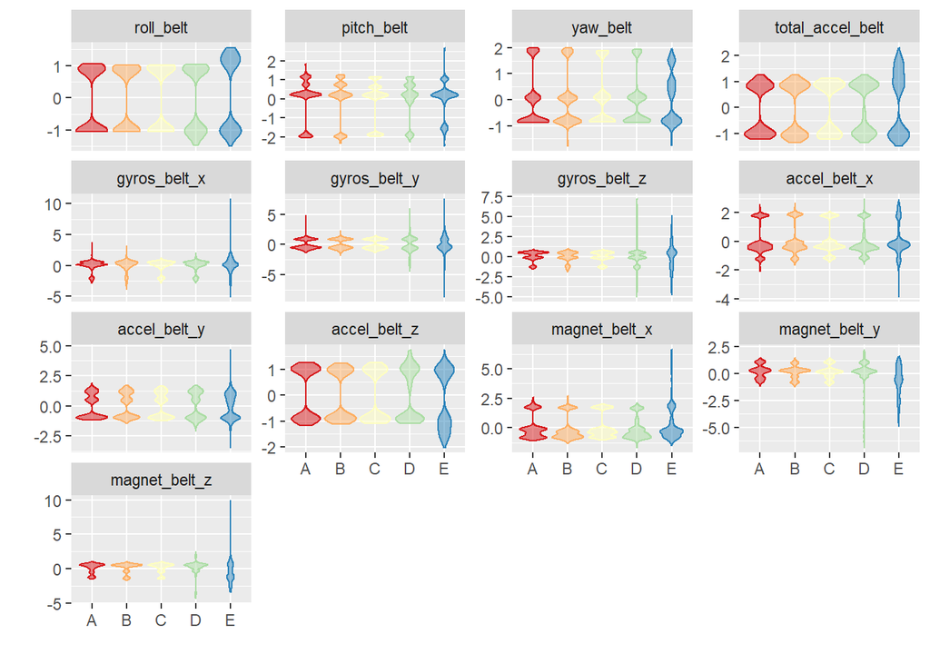

```r
histograms <- function (data, regex) {
  col <- grep(regex, names(data))
  col <- c(col, which(names(data) == "classe"))
  require(reshape2)
  n <- nrow(data)
  XMelt <- melt(data[, col, with=FALSE][, rownum := seq(1, n)], id.vars=c("rownum", "classe"))
  require(ggplot2)
  ggplot(XMelt, aes(x=classe, y=value)) +
    geom_violin(aes(color=classe, fill=classe), alpha=1/2) +
    facet_wrap(~ variable, scale="free_y") +
    scale_color_brewer(palette="Spectral") +
    scale_fill_brewer(palette="Spectral") +
    labs(x="", y="") +
    theme(legend.position="none")
}
histograms(XTrain, "belt")
```

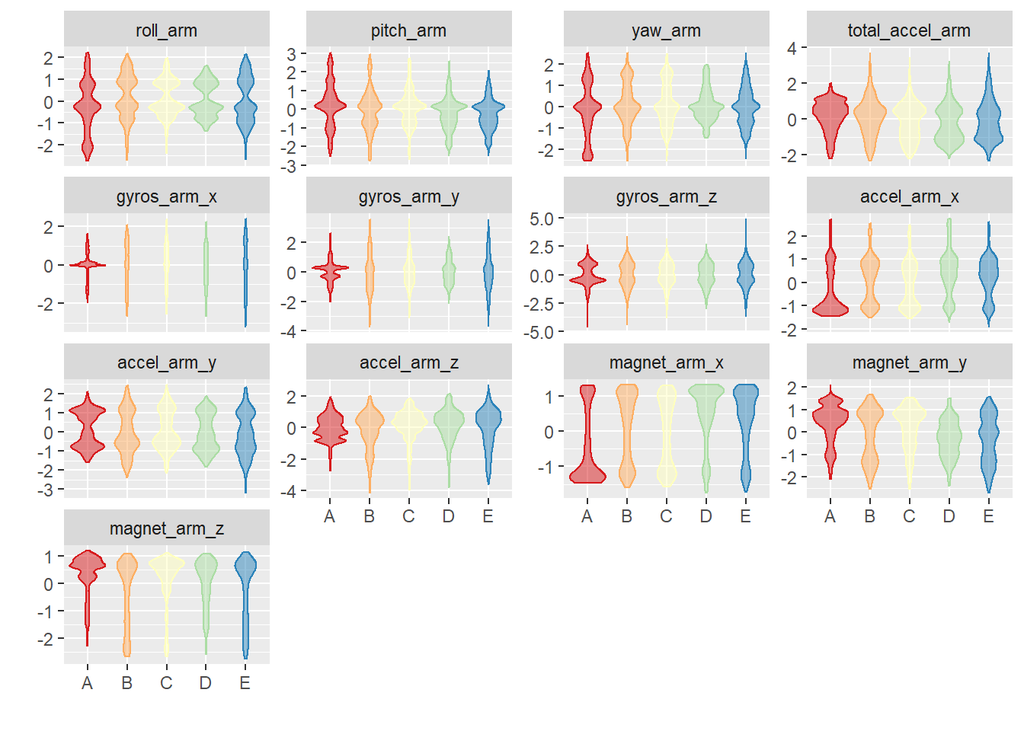

```r
histograms(XTrain, "[^(fore)]arm")
```

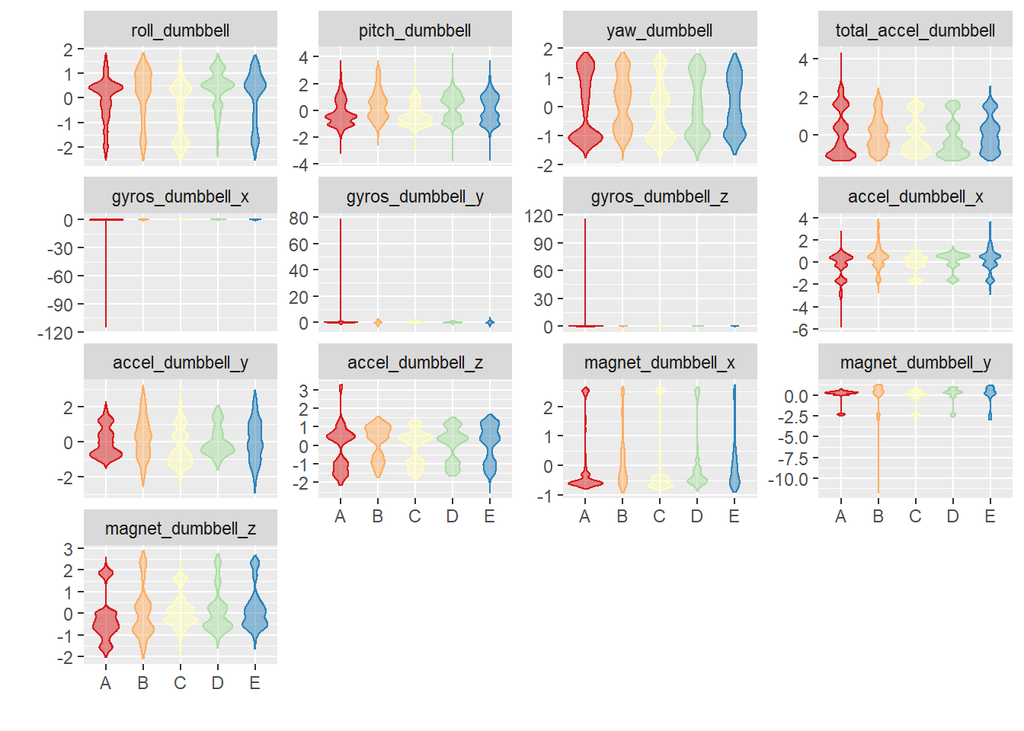

```r
histograms(XTrain, "dumbbell")
```

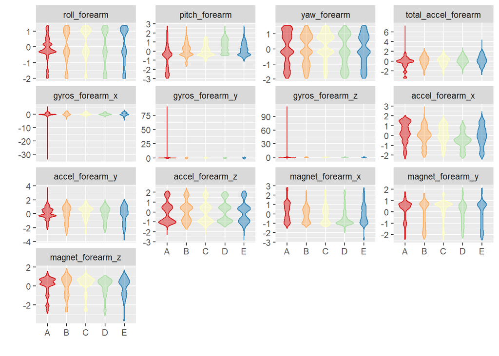

```r
histograms(XTrain, "forearm")
```